# Final Project BANA 4137

Group 11

12/3/2020

### Team Members:

*Leah N Lai M13526802

*Janae Dawson M12171077

*Anh Ngo M12040145

*Emma Bell M12167203

## Contents

##### 1. Introduction

##### 2. Load Packages

##### 3. Prepare the Data

##### 4. EDA

##### 5. Visualizations - Emma

##### 6. Visualizations - Janae

##### 7. Visualizations - Anh

##### 8. Visualizations - Leah

##### 9. Conclusion

# Part 1: Introduction

The data were obtained in a survey of students Portuguese language courses in secondary school. It contains a lot of interesting social, gender and study information about students. We can use it for some EDA or answer some questions to predict students’ class performance.

*Data Source:* (https://www.kaggle.com/uciml/student-alcohol-consumption)

## Variable Meanings

- school - student’s school (binary: ‘GP’ - Gabriel Pereira or ‘MS’ - Mousinho da Silveira)
- sex - student’s sex (binary: ‘F’ - female or ‘M’ - male)
- age - student’s age (numeric: from 15 to 22)
- address - student’s home address type (binary: ‘U’ - urban or ‘R’ - rural)
- famsize - family size (binary: ‘LE3’ - less or equal to 3 or ‘GT3’ - greater than 3)
- Pstatus - parent’s cohabitation status (binary: ‘T’ - living together or ‘A’ - apart)
- Medu - mother’s education (numeric: 0 - none, 1 - primary education (4th grade), 2 – 5th to 9th grade, 3 – secondary education or 4 – higher education)
- Fedu - father’s education (numeric: 0 - none, 1 - primary education (4th grade), 2 – 5th to 9th grade, 3 – secondary education or 4 – higher education)
- Mjob - mother’s job (nominal: ‘teacher’, ‘health’ care related, civil ‘services’ (e.g. administrative or police), ‘at_home’ or ‘other’)
- Fjob - father’s job (nominal: ‘teacher’, ‘health’ care related, civil ‘services’ (e.g. administrative or police), ‘at_home’ or ‘other’)
- reason - reason to choose this school (nominal: close to ‘home’, school ‘reputation’, ‘course’ preference or ‘other’)
- guardian - student’s guardian (nominal: ‘mother’, ‘father’ or ‘other’)
- traveltime - home to school travel time (numeric: 1 - 1 hour)
- studytime - weekly study time (numeric: 1 - 10 hours)
- failures - number of past class failures (numeric: n if 1<=n<3, else 4)
- schoolsup - extra educational support (binary: yes or no)
- famsup - family educational support (binary: yes or no)
- paid - extra paid classes within the course subject (Math or Portuguese) (binary: yes or no)
- activities - extra-curricular activities (binary: yes or no)
- nursery - attended nursery school (binary: yes or no)
- higher - wants to take higher education (binary: yes or no)
- internet - Internet access at home (binary: yes or no)
- romantic - with a romantic relationship (binary: yes or no)
- famrel - quality of family relationships (numeric: from 1 - very bad to 5 - excellent)
- freetime - free time after school (numeric: from 1 - very low to 5 - very high)
- goout - going out with friends (numeric: from 1 - very low to 5 - very high)
- Dalc - workday alcohol consumption (numeric: from 1 - very low to 5 - very high)
- Walc - weekend alcohol consumption (numeric: from 1 - very low to 5 - very high)
- health - current health status (numeric: from 1 - very bad to 5 - very good)
- absences - number of school absences (numeric: from 0 to 93)

*These grades are related with the course subject, Math or Portuguese:*

- G1 - first period grade (numeric: from 0 to 20)
- G2 - second period grade (numeric: from 0 to 20)
- G3 - final grade (numeric: from 0 to 20, output target)

# Part 2: Load Packages

```r
#install & run packages
library(tidyverse)
```

```r
library(dplyr)
library(ggplot2)
library(tidyverse)
library(RColorBrewer)
```

# Part 3: Prepare the Data

**Import the data and identify the structure**

```r
students.df <- read.csv("student-por.csv", stringsAsFactors = TRUE)
summary(students.df)
```

```
##  school   sex          age        address famsize   Pstatus      Medu
##  GP:423   F:383   Min.   :15.00   R:197   GT3:457   A: 80   Min.   :0.000
##  MS:226   M:266   1st Qu.:16.00   U:452   LE3:192   T:569   1st Qu.:2.000
##                   Median :17.00                             Median :2.000
##                   Mean   :16.74                             Mean   :2.515
##                   3rd Qu.:18.00                             3rd Qu.:4.000
##                   Max.   :22.00                             Max.   :4.000
##       Fedu             Mjob           Fjob            reason      guardian
##  Min.   :0.000   at_home :135   at_home : 42   course    :285   father:153
##  1st Qu.:1.000   health  : 48   health  : 23   home      :149   mother:455
##  Median :2.000   other   :258   other   :367   other     : 72   other : 41
##  Mean   :2.307   services:136   services:181   reputation:143
##  3rd Qu.:3.000   teacher : 72   teacher : 36
##  Max.   :4.000
##    traveltime      studytime        failures      schoolsup famsup     paid
##  Min.   :1.000   Min.   :1.000   Min.   :0.0000   no :581   no :251   no :610
##  1st Qu.:1.000   1st Qu.:1.000   1st Qu.:0.0000   yes: 68   yes:398   yes: 39
##  Median :1.000   Median :2.000   Median :0.0000
##  Mean   :1.569   Mean   :1.931   Mean   :0.2219
##  3rd Qu.:2.000   3rd Qu.:2.000   3rd Qu.:0.0000
##  Max.   :4.000   Max.   :4.000   Max.   :3.0000
##  activities nursery   higher    internet  romantic      famrel
##  no :334    no :128   no : 69   no :151   no :410   Min.   :1.000
##  yes:315    yes:521   yes:580   yes:498   yes:239   1st Qu.:4.000
##                                                     Median :4.000
##                                                     Mean   :3.931
##                                                     3rd Qu.:5.000
##                                                     Max.   :5.000
##     freetime        goout            Dalc            Walc          health
##  Min.   :1.00   Min.   :1.000   Min.   :1.000   Min.   :1.00   Min.   :1.000
##  1st Qu.:3.00   1st Qu.:2.000   1st Qu.:1.000   1st Qu.:1.00   1st Qu.:2.000
##  Median :3.00   Median :3.000   Median :1.000   Median :2.00   Median :4.000
##  Mean   :3.18   Mean   :3.185   Mean   :1.502   Mean   :2.28   Mean   :3.536
##  3rd Qu.:4.00   3rd Qu.:4.000   3rd Qu.:2.000   3rd Qu.:3.00   3rd Qu.:5.000
##  Max.   :5.00   Max.   :5.000   Max.   :5.000   Max.   :5.00   Max.   :5.000
##     absences            G1             G2              G3
##  Min.   : 0.000   Min.   : 0.0   Min.   : 0.00   Min.   : 0.00
##  1st Qu.: 0.000   1st Qu.:10.0   1st Qu.:10.00   1st Qu.:10.00
##  Median : 2.000   Median :11.0   Median :11.00   Median :12.00
##  Mean   : 3.659   Mean   :11.4   Mean   :11.57   Mean   :11.91
##  3rd Qu.: 6.000   3rd Qu.:13.0   3rd Qu.:13.00   3rd Qu.:14.00
##  Max.   :32.000   Max.   :19.0   Max.   :19.00   Max.   :19.00
```

```r
str(students.df)
```

```
## 'data.frame':    649 obs. of  33 variables:
##  $ school    : Factor w/ 2 levels "GP","MS": 1 1 1 1 1 1 1 1 1 1 ...
##  $ sex       : Factor w/ 2 levels "F","M": 1 1 1 1 1 2 2 1 2 2 ...
##  $ age       : int  18 17 15 15 16 16 16 17 15 15 ...
##  $ address   : Factor w/ 2 levels "R","U": 2 2 2 2 2 2 2 2 2 2 ...
##  $ famsize   : Factor w/ 2 levels "GT3","LE3": 1 1 2 1 1 2 2 1 2 1 ...
##  $ Pstatus   : Factor w/ 2 levels "A","T": 1 2 2 2 2 2 2 1 1 2 ...
##  $ Medu      : int  4 1 1 4 3 4 2 4 3 3 ...
##  $ Fedu      : int  4 1 1 2 3 3 2 4 2 4 ...
##  $ Mjob      : Factor w/ 5 levels "at_home","health",..: 1 1 1 2 3 4 3 3 4 3 ...
##  $ Fjob      : Factor w/ 5 levels "at_home","health",..: 5 3 3 4 3 3 3 5 3 3 ...
##  $ reason    : Factor w/ 4 levels "course","home",..: 1 1 3 2 2 4 2 2 2 2 ...
##  $ guardian  : Factor w/ 3 levels "father","mother",..: 2 1 2 2 1 2 2 2 2 2 ...
##  $ traveltime: int  2 1 1 1 1 1 1 2 1 1 ...
##  $ studytime : int  2 2 2 3 2 2 2 2 2 2 ...
```

[output cut: 19 more lines]

*Observations:* There are 2 different schools within this dataset… ‘GP’ - Gabriel Pereira or ‘MS’ - Mousinho da Silveira). Each variable is also either integer or factor, which may need to be converted to numeric and character for certain visualizations.

# Part 4: EDA

**Explore the Data**

```r
#Data exploratory
#Which school has the most study times?
ranking <- group_by(students.df, school) %>%
         summarize(students.df = mean(studytime)) %>%
         as.data.frame %>% arrange(desc(students.df))
head(ranking, 2)
```

```
##   school students.df
## 1     GP    2.014184
## 2     MS    1.774336
```

*Observation:* We can see that GP’s students spend the most time studying. The average of GP is 2 hours, compared to MS which is closed to 2 as well.

**EDA visualizations**

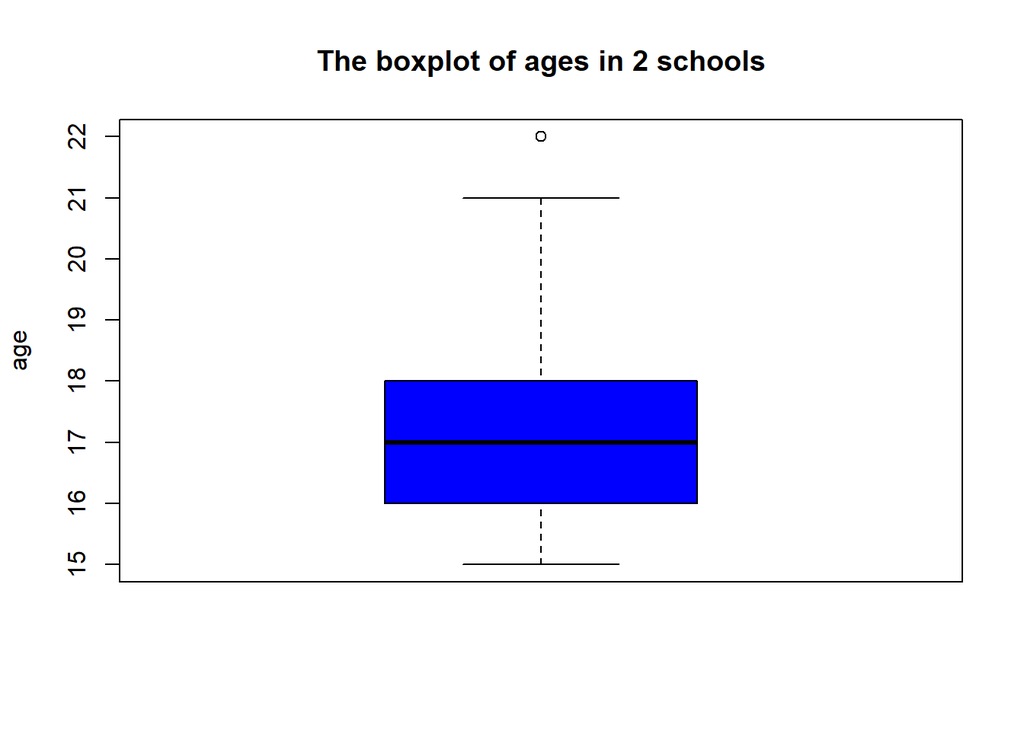

```r
#box plot of ages
boxplot(students.df$age, col = "blue", ylab = 'age', main = 'The boxplot of ages in 2 schools')
```

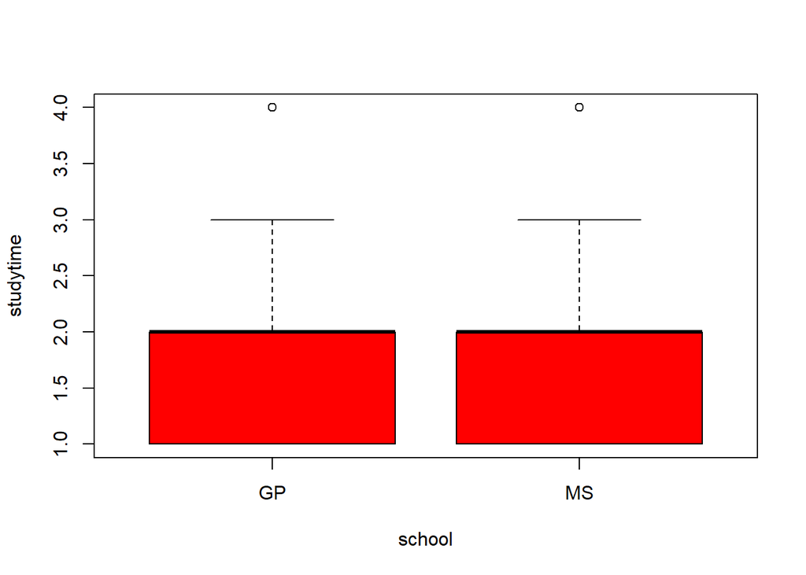

```r
#Box plot of study times
boxplot(studytime ~ school, data = students.df, col = "red")
```

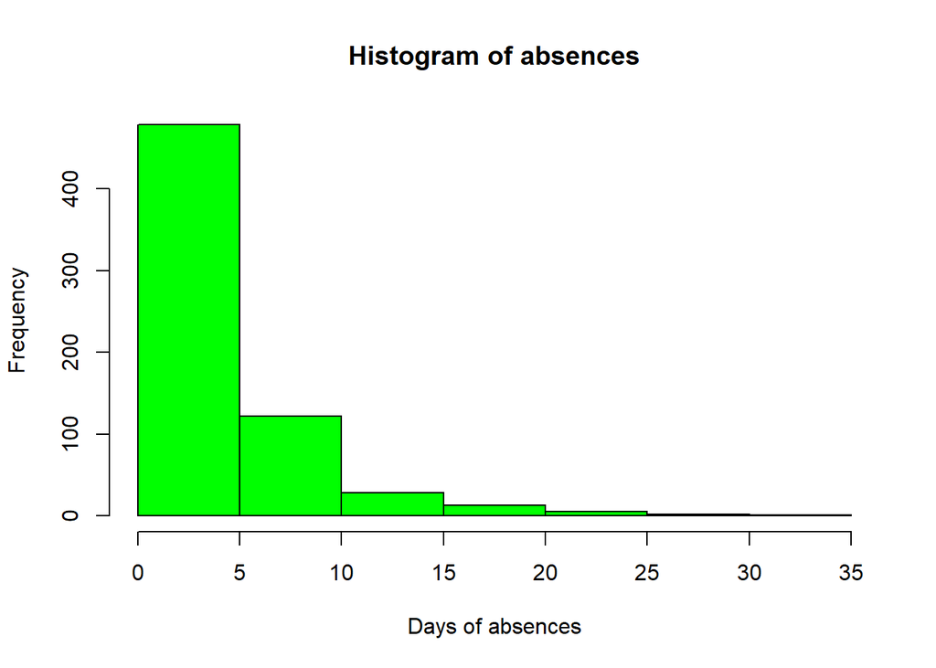

```r
#Frequency of absences
hist(students.df$absences, col = "green", xlab = 'Days of absences', main = 'Histogram of absences')
```

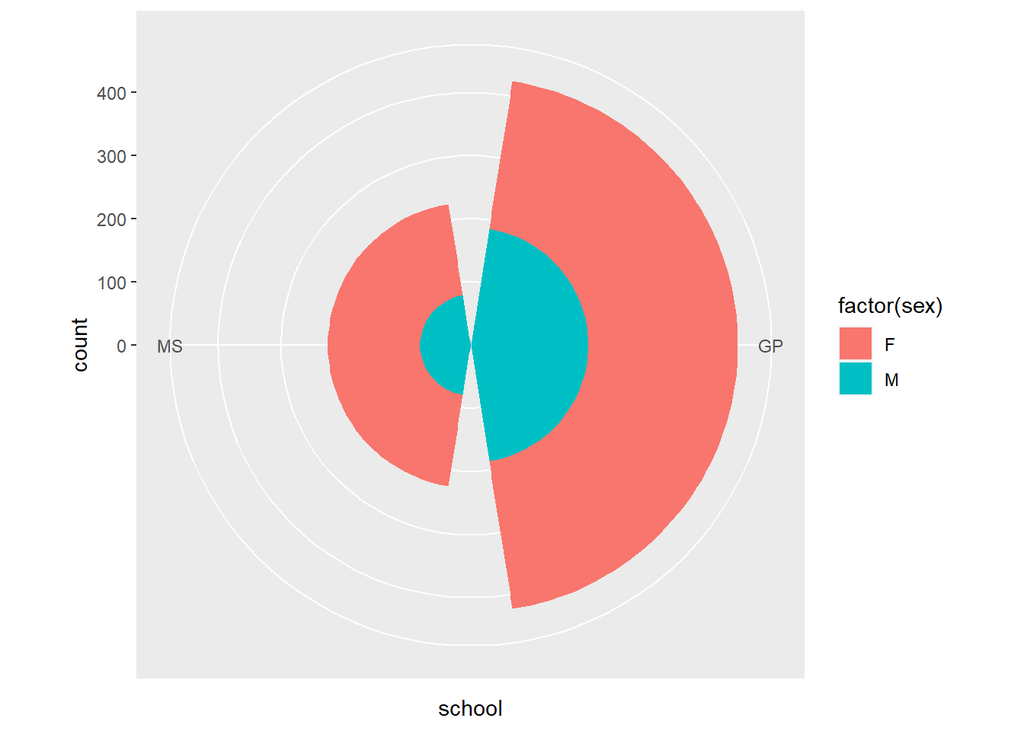

```r
#distribution of genders in two schools
ggplot(data=students.df,aes(school,fill=factor(sex))) +  geom_bar() +  coord_polar()
```

**EDA of alcohol consumption**

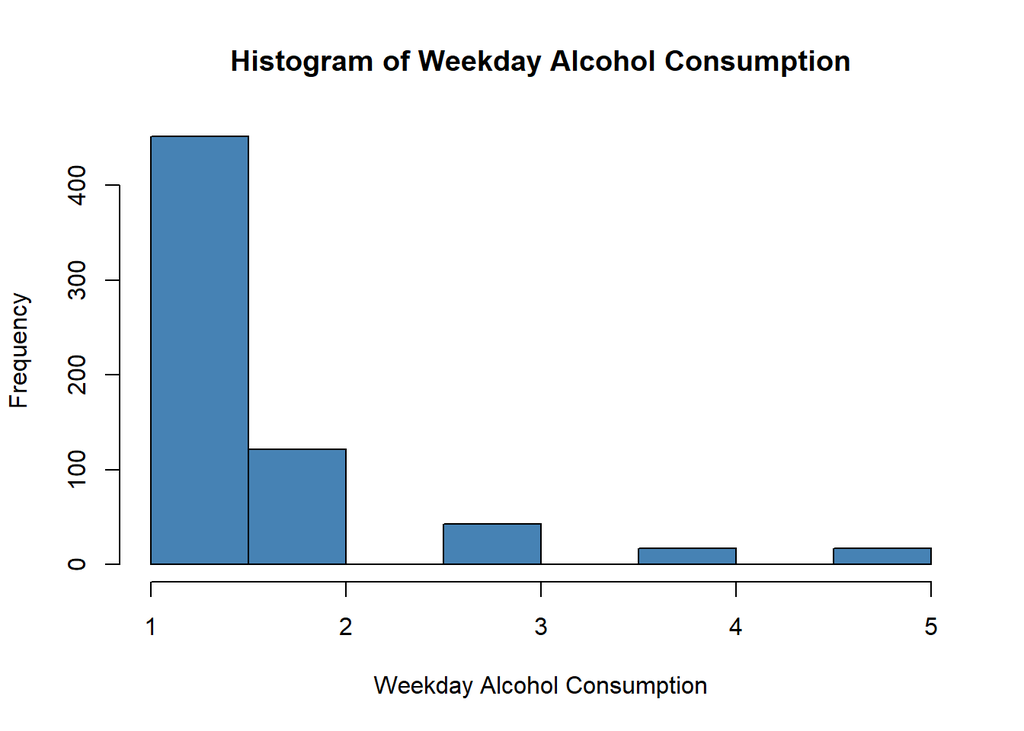

```r
# distribution of workday alcohol consumption
hist(students.df$Dalc, col = "Steel blue", xlab = 'Weekday Alcohol Consumption', main = 'Histogram of Weekday Alcohol Consumption')
```

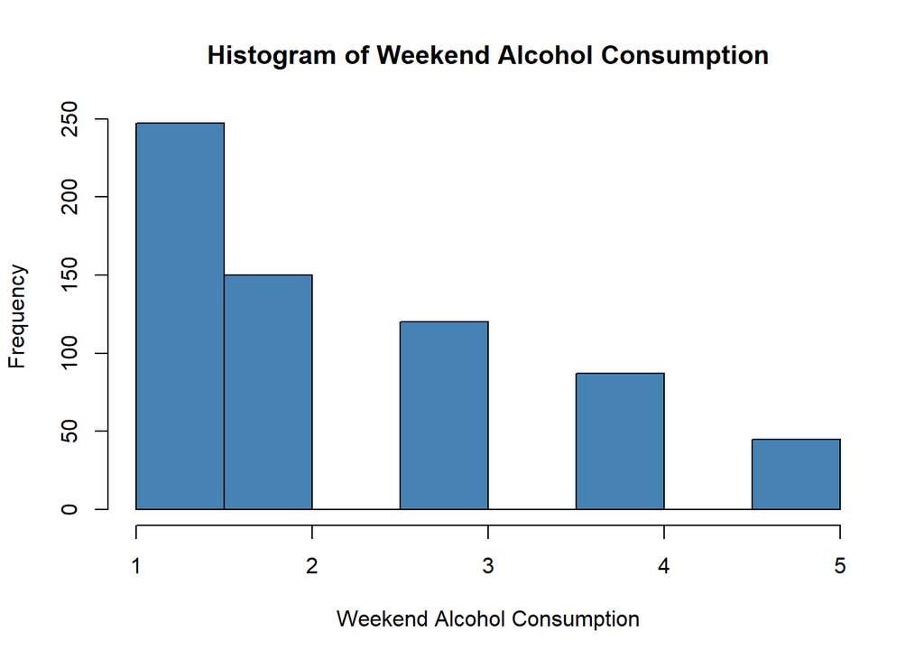

```r
# distribution of weekend alcohol consumption
hist(students.df$Walc, col = "Steel blue", xlab = 'Weekend Alcohol Consumption', main = 'Histogram of Weekend Alcohol Consumption')
```

*Observations:* Here we can see that alcohol is consumed more frequently on the weekends than on the weekdays for students at GP and MS. What variables could influence this?

# Part 5: Visualizations - Emma

## **Do students who do not participate in extracurricular activities drink more during the workday?**

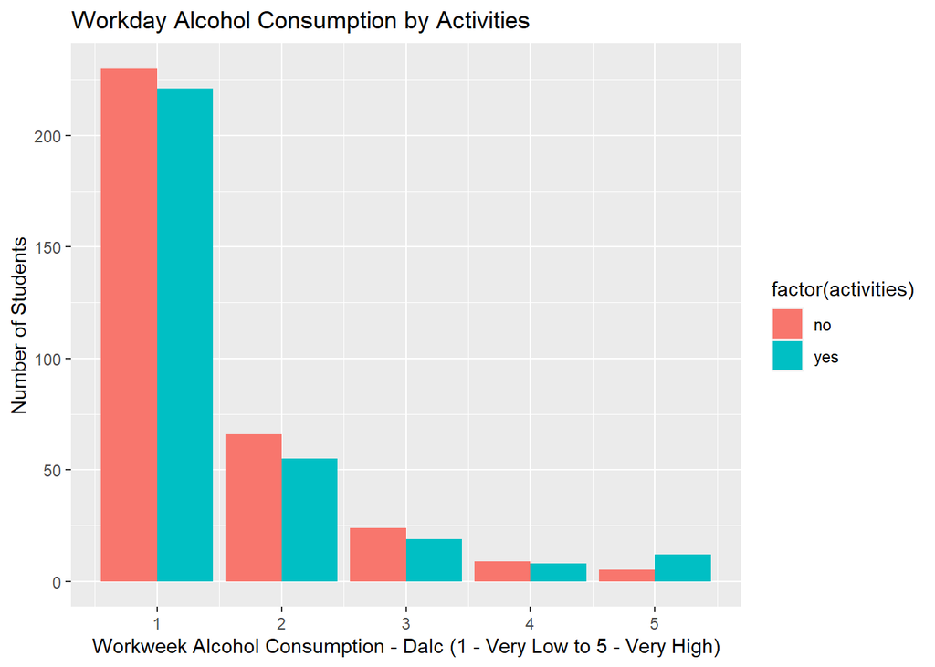

```r
p19 <- ggplot(data=students.df,aes(x=Dalc,fill=factor(activities))) +
  geom_bar(position="dodge")
p19 + geom_bar(stat = "count", position = "dodge") +
  labs(title = "Workday Alcohol Consumption by Activities",  x = "Workweek Alcohol Consumption - Dalc (1 - Very Low to 5 - Very High)", y = "Number of Students")
```

*Observations:* This graph shows that, within this dataset, slightly more students who participated in extracurricular activities consume very high amounts of alcohol during the workday compared to students who do not participate in extracurricular actvities. It also shows that slightly more students who do not participate in extracurricular activities consume very low amounts of alcohol compared to those who do participate in extracurricular activities.

## **Do males consume more alcohol during the workday compared to females?**

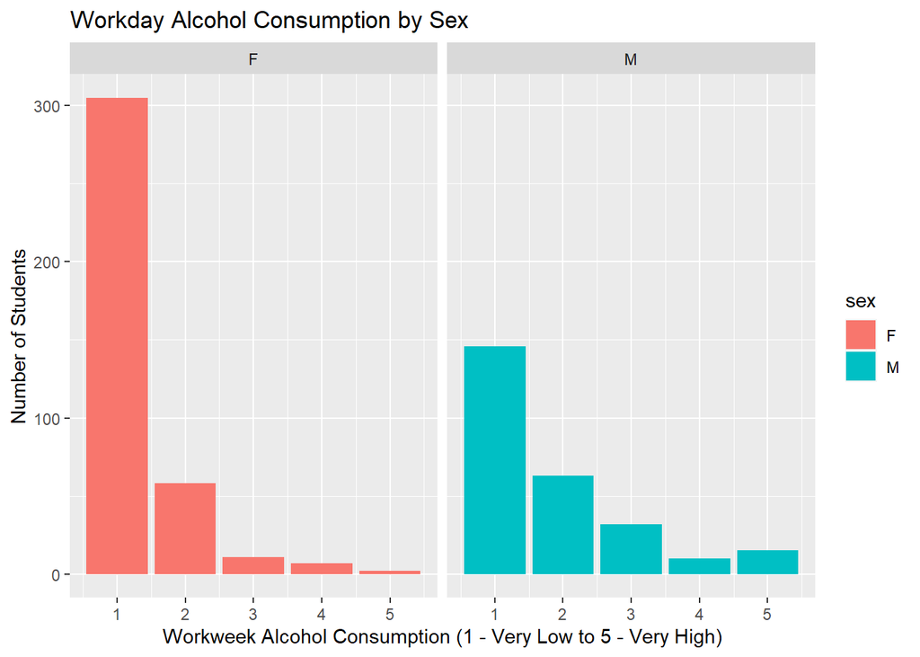

```r
p2 <- ggplot(data = students.df, aes(x = Dalc, fill = sex ))
p2 + geom_bar(stat = "count", position = "dodge") +
  labs(title = "Workday Alcohol Consumption by Sex",  x = "Workweek Alcohol Consumption (1 - Very Low to 5 - Very High)", y = "Number of Students") + facet_wrap(~ sex)
```

*Observations:* This graph shows that, within this dataset, twice as many females consume very low amounts of alcohol compared to the males, while slightly more males consume very high amounts of alcohol during the workday compared to females.

# Part 6: Visualizations - Janae

## **How does Weekend Alcohol Consumption Relate to Absences for Each School?**

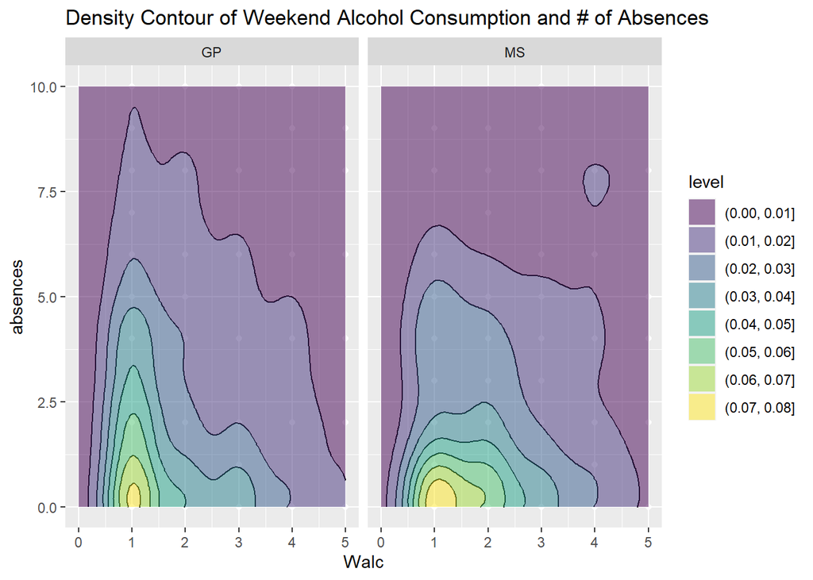

```r
# create a density plot to better see the distribution
ggplot(students.df,aes(x=Walc,y=absences))+
  geom_point(colour="white",alpha=0.9)+              #delete point
  geom_density_2d(color="black")+                    #draw the density plot
  geom_density_2d_filled(alpha=0.5)+                 #fill color
  facet_wrap(vars(school))+                         #facet
  labs(title = "Density Contour of Weekend Alcohol Consumption and # of Absences") +
  xlim(0,5) +
  ylim(0,10)
```

*Observations:* Here we can see that at GP, students are absent more, and have more students with a higher weekend alcohol consumption. Also, it appears that the GP school has higher weekend alcohol consumption as the base of the density plot here is wider. For the students at MS, the students are absent less, and less frequency of a higher weekend alcohol consumption.

## **How does Weekday Alcohol Consumption Relate to Absences for Each School?**

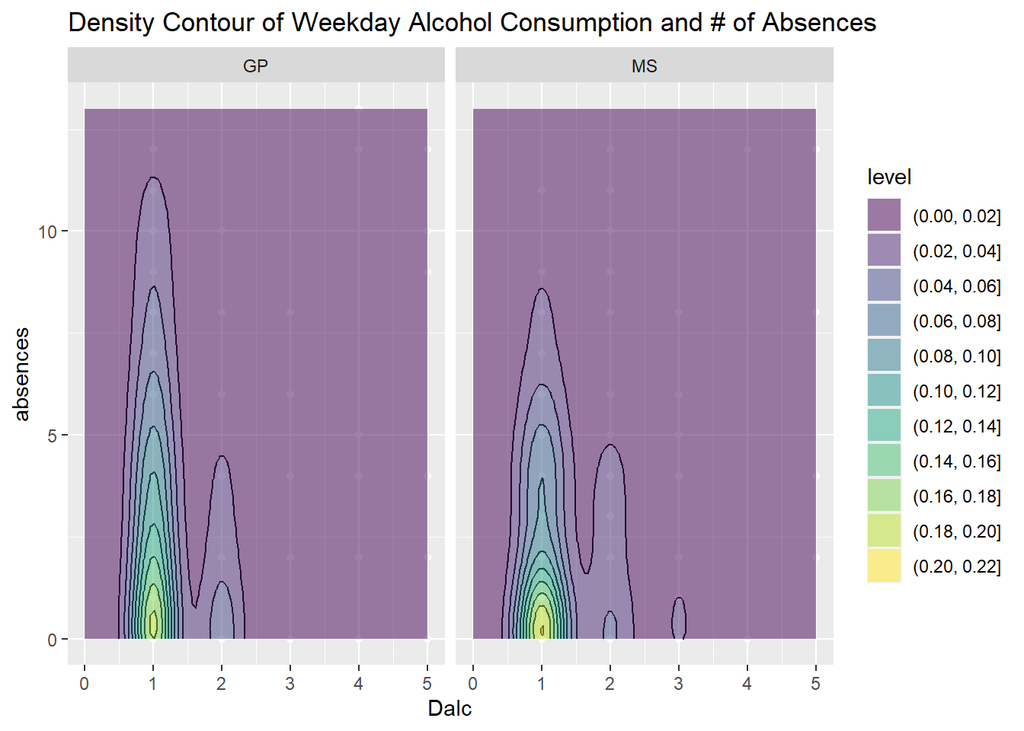

```r
# create a density plot to better see the distribution
ggplot(students.df,aes(x=Dalc,y=absences))+
  geom_point(colour="white",alpha=0.9)+              #delete point
  geom_density_2d(color="black")+                    #draw the density plot
  geom_density_2d_filled(alpha=0.5)+                 #fill color
  facet_wrap(vars(school))+                         #facet
  labs(title = "Density Contour of Weekday Alcohol Consumption and # of Absences") +
  xlim(0,5) +
  ylim(0,13)
```

*Observations:*Here we can see a bit of a different distribution as there’s less alcohol consumption for both schools, as well as both mimic a similar pattern of lots of observations in the 1 range, a dip, then a little more in the 2 range for alcohol consumption.

## **Do students with separated parents have a higher alcohol consumption?**

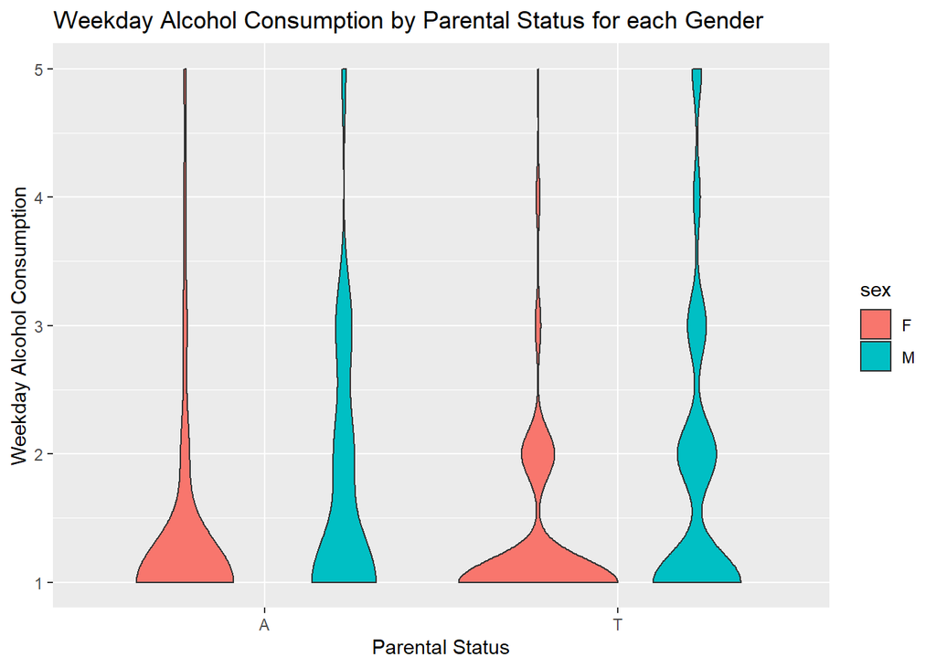

```r
# create a violin plot for weekday alcohol consumption
ggplot(students.df,aes(Pstatus,Dalc,fill=sex))+
  geom_violin() +
   labs(title = "Weekday Alcohol Consumption by Parental Status for each Gender",
       x = "Parental Status", y = "Weekday Alcohol Consumption", colour = "Gender")
```

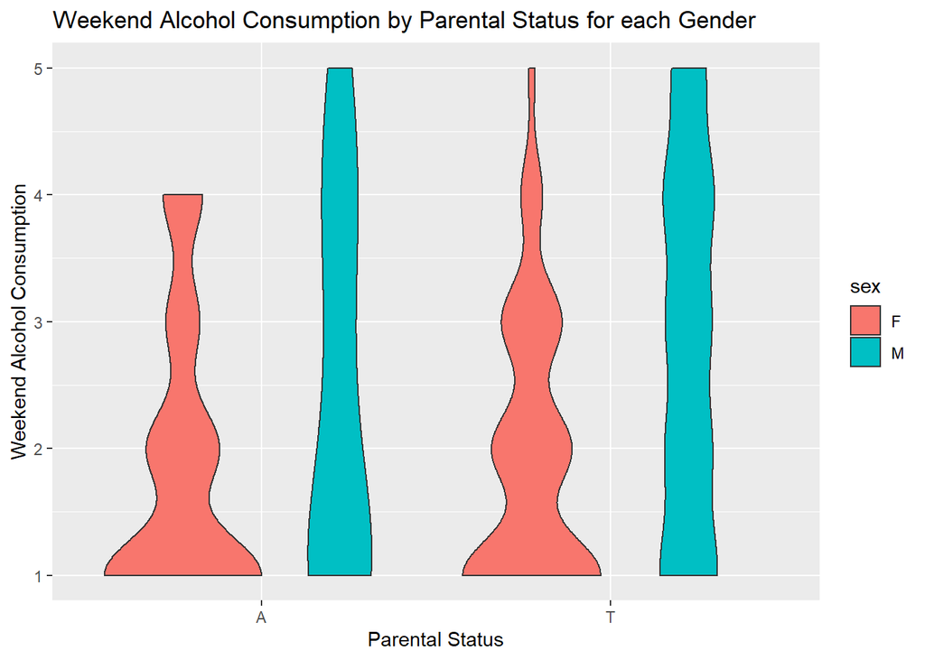

```r
# create a violin plot for weekend alcohol consumption
ggplot(students.df,aes(Pstatus,Walc,fill=sex))+
 geom_violin() +
   labs(title = "Weekend Alcohol Consumption by Parental Status for each Gender",
       x = "Parental Status", y = "Weekend Alcohol Consumption", colour = "Gender")
```

*Observations:*Interestingly we can see that male students tend to have the same pattern for parents that are together, as well as apart. Female students with parents that are together have a long peak, drinking very much, meaning there could be some outlier students that don’t mimic the overall trend.

# Part 7: Visualizations - Anh

```r
# Correlation between parents job and students final grades grouped by family supports
## Mother
names(students.df)
```

```
##  [1] "school"     "sex"        "age"        "address"    "famsize"
##  [6] "Pstatus"    "Medu"       "Fedu"       "Mjob"       "Fjob"
## [11] "reason"     "guardian"   "traveltime" "studytime"  "failures"
## [16] "schoolsup"  "famsup"     "paid"       "activities" "nursery"
## [21] "higher"     "internet"   "romantic"   "famrel"     "freetime"
## [26] "goout"      "Dalc"       "Walc"       "health"     "absences"
## [31] "G1"         "G2"         "G3"
```

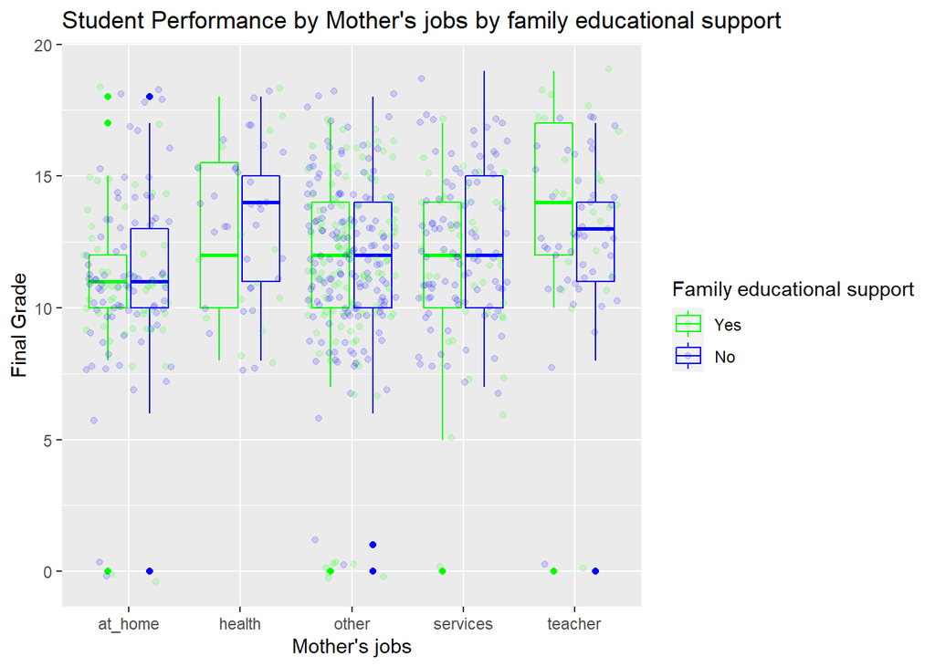

```r
p3 <- ggplot(data = students.df, aes(x = Mjob, y = G3, colour = famsup))
p3 + geom_boxplot(fill = NA) + geom_jitter(alpha = 0.15) +
  labs(title = "Student Performance by Mother's jobs by family educational support",
       x = "Mother's jobs", y = "Final Grade", colour = "Family educational support") +
  scale_colour_manual(labels = c("Yes", "No"),
                      values = c("green", "blue"))
```

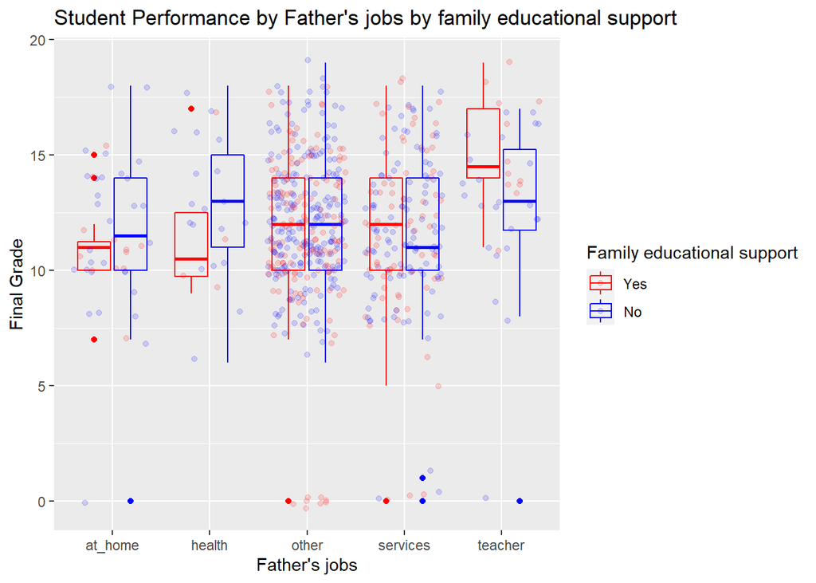

```r
## Father
p4 <- ggplot(data = students.df, aes(x = Fjob, y = G3, colour = famsup))
p4 + geom_boxplot(fill = NA) + geom_jitter(alpha = 0.15) +
  labs(title = "Student Performance by Father's jobs by family educational support",
       x = "Father's jobs", y = "Final Grade", colour = "Family educational support") +
  scale_colour_manual(labels = c("Yes", "No"),
                      values = c("red", "blue"))
```

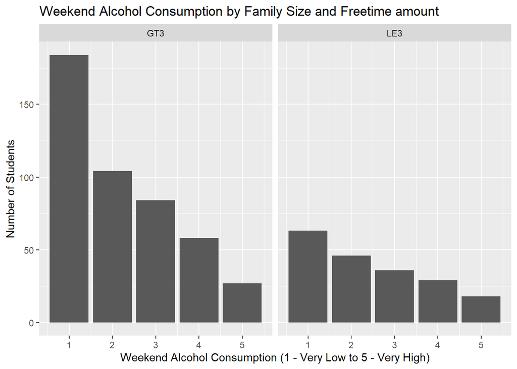

```r
# Correlation between students free time and weekdays alcohol consumption
p5 <- ggplot(data = students.df, aes(x = Walc, fill = freetime ))
p5 + geom_bar(stat = "count", position = "dodge") +
  labs(title = "Weekend Alcohol Consumption by Family Size and Freetime amount",  x = "Weekend Alcohol Consumption (1 - Very Low to 5 - Very High)",
       y = "Number of Students", colour = "Freetime amount") +
  facet_wrap(~ famsize)
```

*Observations:* The students that have a a family greater than 3 tends to drink more than half of the students with family less than 3; however, they only drink a small amount per day, but the number of students drink more than ‘very low’ level’ steadily decreases on the consumption

## **Correlation between students grade and parent’s occupation grouped by family size**

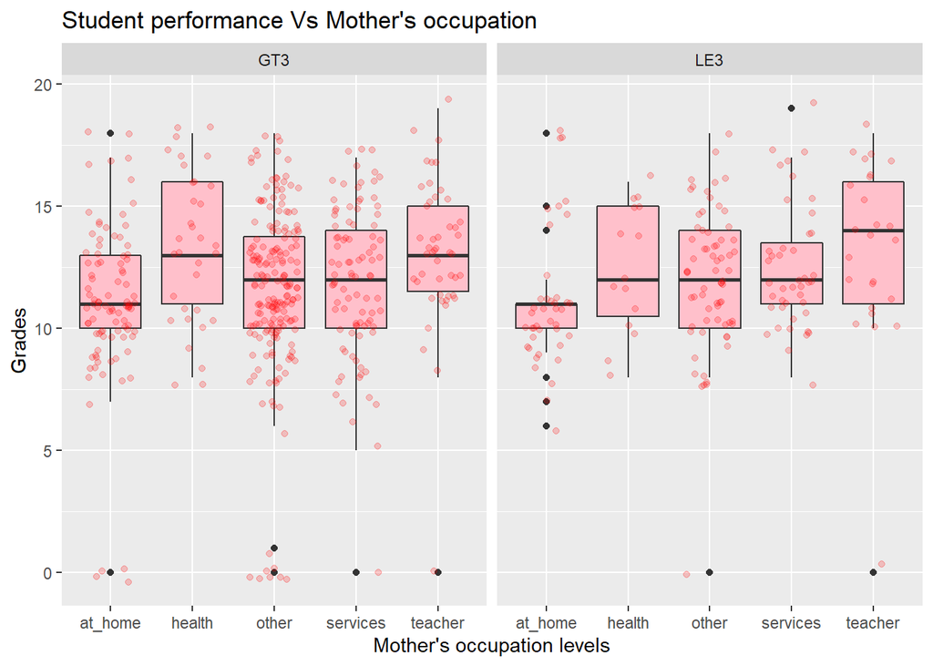

```r
# Correlation between students grade and parent’s occupation grouped by family size ( more than 3 and less than 3)

## Mother
ggplot(students.df, aes(x = Mjob, y = G3,group=Mjob)) + geom_boxplot(fill=" pink") + facet_wrap(~famsize)+ggtitle("Student performance Vs Mother's occupation")+ylab("Grades")+xlab("Mother's occupation levels")+
  geom_jitter(width=0.3, alpha =0.2,color="red")
```

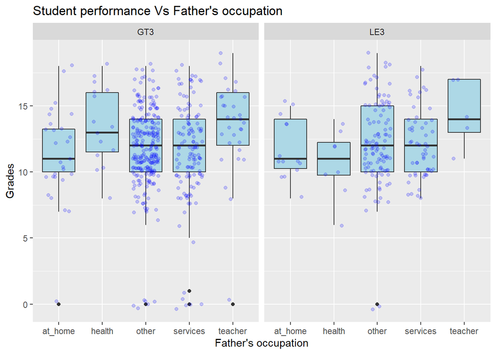

```r
## Father
ggplot(students.df, aes(x = Fjob, y = G3,group=Fjob)) + geom_boxplot(fill="light blue") + facet_wrap(~famsize)+ggtitle("Student performance Vs Father's occupation")+ylab("Grades")+xlab("Father's occupation")+
  geom_jitter(width=0.3, alpha =0.2,color="blue")
```

# Part 8: Visualizations - Leah

**MAIN QUESTION: How Does Alcohol Consumption Correlate with Gender and Class Performance?**

*Firstly, we can look into the final results by gender. Let’s see if they are approximately the same within schools or whether the performance is different between female and male gender.*

## **How is Student Performance Related to Gender?**

```r
#data manipulation
#Convert integer values to factors
students.dfMedu <- as.factor(students.df$Medu)
students.df$Fedu <- as.factor(students.df$Fedu)
students.df$traveltime <- as.factor(students.df$traveltime)
students.df$studytime <- as.factor(students.df$studytime)
students.df$failures <- as.factor(students.df$failures)
students.df$famrel <- as.factor(students.df$famrel)
students.df$freetime <- as.factor(students.df$freetime)
students.df$goout <- as.factor(students.df$goout)
students.df$Walc <- as.factor(students.df$Walc)
students.df$Dalc <- as.factor(students.df$Dalc)
students.df$health <- as.factor(students.df$health)
students.df$absences <- as.factor(students.df$absences)
```

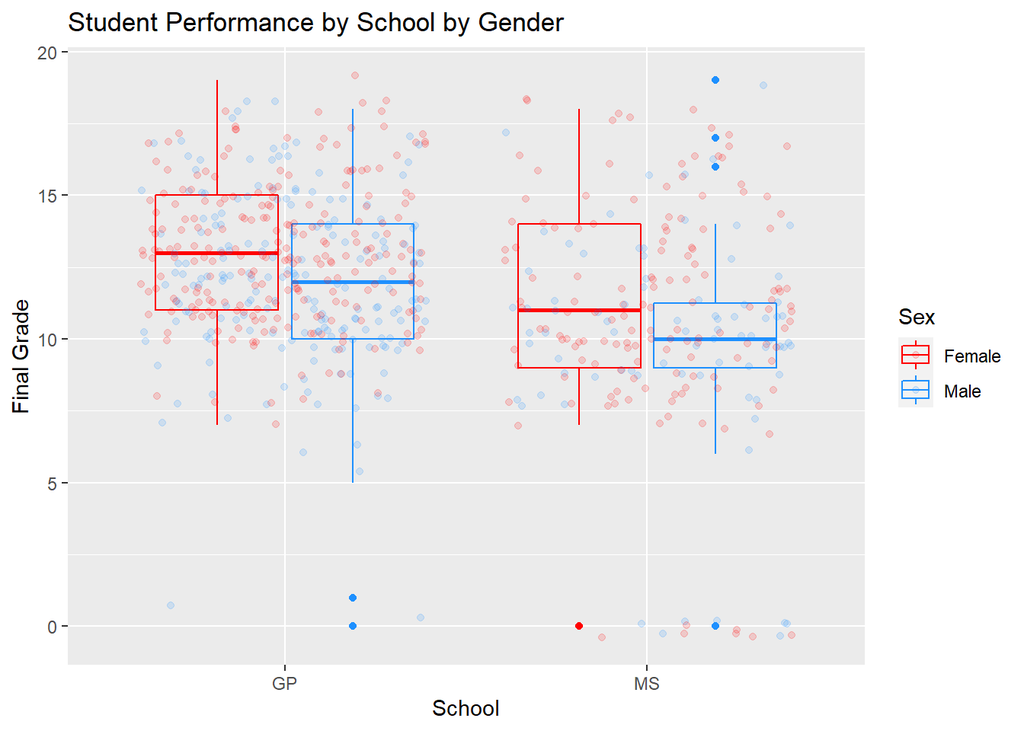

```r
GP <- filter(students.df, school == "GP")
MS <- filter(students.df, school == "MS")
Students <- rbind(GP, MS)

p1 <- ggplot(data = students.df, aes(x = school, y = G3, colour = sex))
p1 + geom_boxplot(fill = NA) + geom_jitter(alpha = 0.15) +
  labs(title = "Student Performance by School by Gender",
       x = "School", y = "Final Grade", colour = "Sex") +
  scale_colour_manual(labels = c("Female", "Male"),
                      values = c("red", "dodgerblue"))
```

*Continuing with the difference between genders, we now can look into the alcohol consumption (weekend) by gender.*